# Pipho_K_Assignment05

Krista Pipho, kp275

March 15, 2021

## Bivariate Regression

Load in the lion nose color dataset

```r
library(tidyverse)
library(ggExtra)

url <- "https://github.com/bio304-class/bio304-course-notes/raw/master/datasets/ABD-lion-noses.csv"
nose_color <- read_csv(url)
glimpse(nose_color)
```

```
## Rows: 32
## Columns: 2
## $ proportionBlack <dbl> 0.21, 0.14, 0.11, 0.13, 0.12, 0.13, 0.12, 0.18, 0.2...
## $ ageInYears      <dbl> 1.1, 1.5, 1.9, 2.2, 2.6, 3.2, 3.2, 2.9, 2.4, 2.1, 1...
```

### Problem 1 a:

Generate a bivariate plot (with marginal histograms) showing the relationship between nose pigmentation (the predictor variable) and age (the dependent variable)

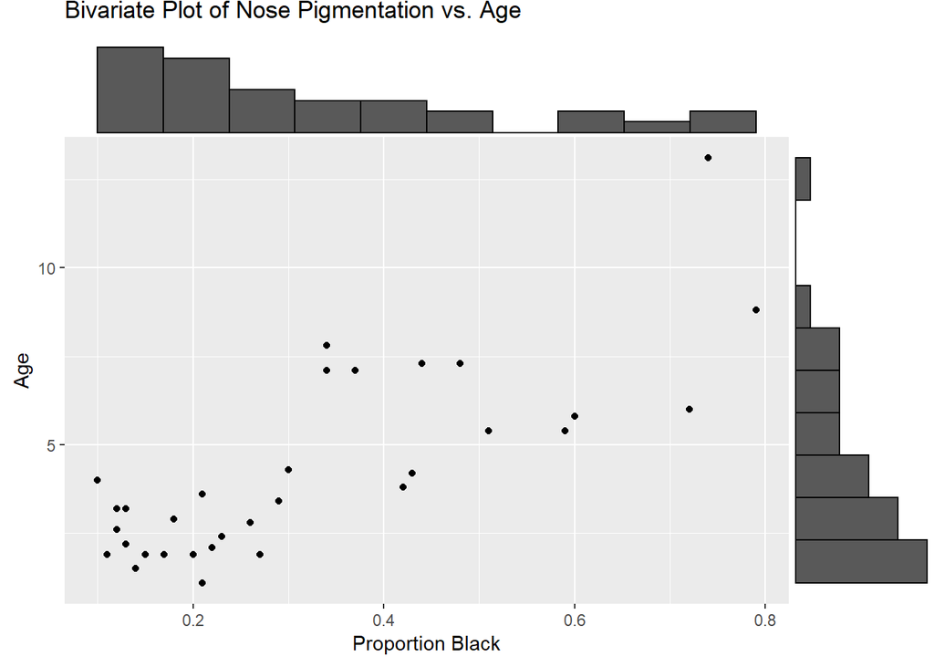

```r
bi_var_marginal_histograms <- ggplot(nose_color, aes(x = proportionBlack, y= ageInYears)) + geom_point() + labs(x = "Proportion Black", y = "Age",
       title = "Bivariate Plot of Nose Pigmentation vs. Age")
ggMarginal(bi_var_marginal_histograms, type = "histogram", bins = 11)
```

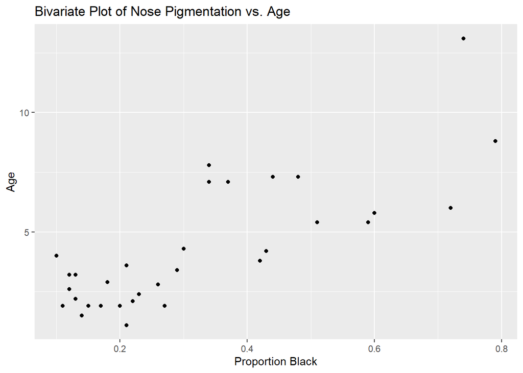

```r
bi_var_marginal_histograms
```

### Problem 1 b:

Using vector operations calculate the regression coefficients for the regression of age on nose pigementation.

```r
# Calculating mean centered vectors
centered_proportionBlack <- nose_color$proportionBlack - mean(nose_color$proportionBlack)
centered_age <- nose_color$ageInYears - mean(nose_color$ageInYears)

# Estimate coefficients
b.est <- (centered_proportionBlack %*% centered_age) / (centered_proportionBlack %*% centered_proportionBlack)
a.est <- mean(nose_color$ageInYears) - b.est * mean(nose_color$proportionBlack)

# 'drop' used to convert to scalar values
regression <-  list(intercept = drop(a.est), slope = drop(b.est))
regression
```

```
## $intercept
## [1] 0.8790062
##
## $slope
## [1] 10.64712
```

### Problem 1 c:

Modify your bivariate plot for problem 1a to illustrate the estimated regression.

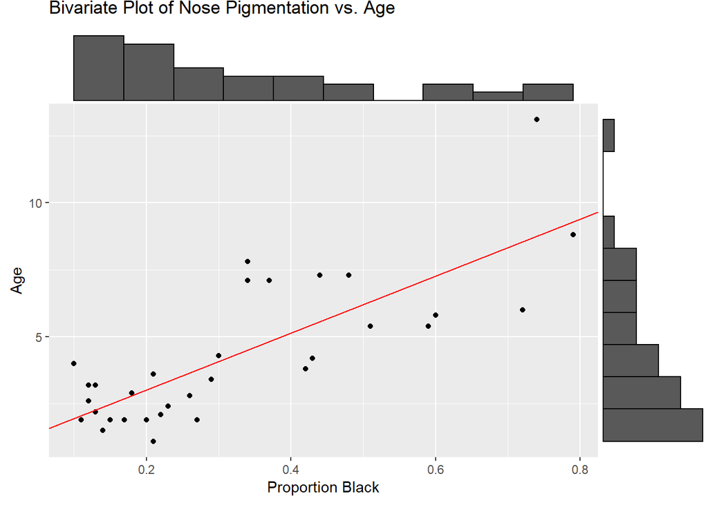

```r
bi_var_marginal_histograms_abline <-  bi_var_marginal_histograms + geom_abline(slope = regression$slope, intercept = regression$intercept, color = "red")
ggMarginal(bi_var_marginal_histograms_abline, type = "histogram", bins = 11)
```

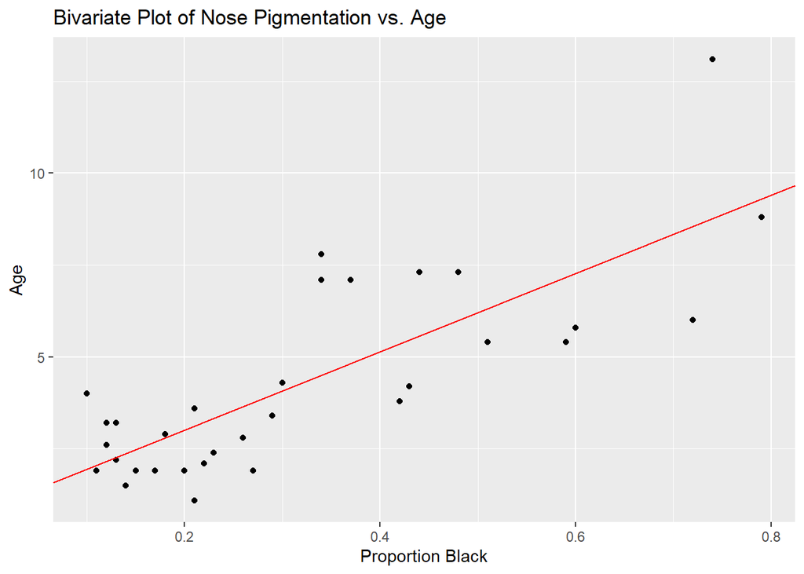

```r
bi_var_marginal_histograms_abline
```

### Problem 1 e:

#### What is the predicted increase in age for a 10% increase in black pigmentation?

The slope (x/y) is 10.64712, thus for each increment of 10% increase in nose pigmentatin we would predict an age increase of 10.64712*0.1 (1.06) years.

### Problem 1 f:

What is the coefficient of determination for your fit model?

```r
# Calculating goodness of fit, or coefficient of determination
age_hat <- regression$intercept + regression$slope * nose_color$proportionBlack

age_hat.ctr <-age_hat - mean(age_hat)

coeff.determination <-  drop(age_hat.ctr %*% age_hat.ctr) / drop(centered_age %*% centered_age)
coeff.determination
```

```
## [1] 0.623827
```

### Problem 1 g:

Generate a residual plot to examine the residuals from the estimated regression. Are the residuals approximately normal? Are the evenly distributed around zero? Are the any signs of trends in the residuals?

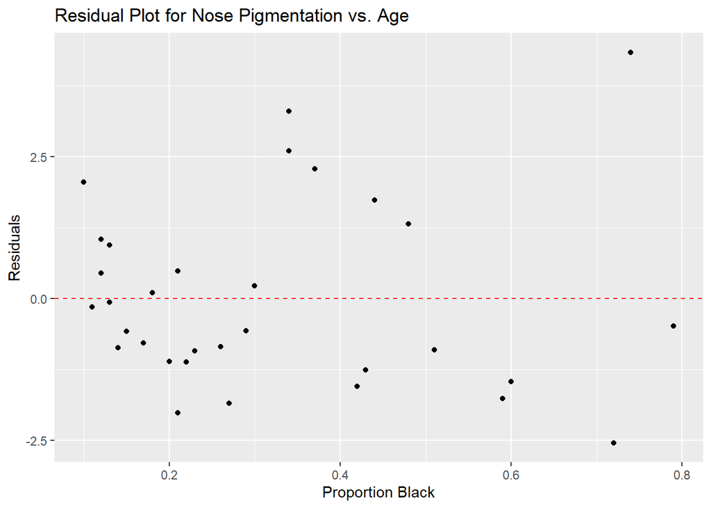

```r
# Calculating the residuals

e <- nose_color$ageInYears - age_hat

regression.df <- tibble(X = nose_color$proportionBlack, Y = nose_color$ageInYears, fitted = age_hat, residuals = e)


# Making a residual plot
ggplot(regression.df, aes(X,residuals)) + geom_point() + geom_hline(yintercept = 0, color = 'red', linetype = 'dashed') + labs(x = "Proportion Black", y = "Residuals", title = "Residual Plot for Nose Pigmentation vs. Age")
```

### Problem 2:

Write your own function bivariate.regression(X, Y) that takes as input two vectors, X and Y, and which calculates the regression of Y on X using vector operations. Your function should return a list object that includes two elements

> a list that includes the slope and intercept of the fitted model

> a data frame that includes the X and Y values, the fitted (predicted) values of Y, and the residual values.

```r
bivariate.regression <- function(x, y) {

# Calculating mean centered vectors
centered_x <- x - mean(x)
centered_y <- y - mean(y)

# Estimate regression coefficients
b.est <- (centered_x %*% centered_y) / (centered_x %*% centered_x)
a.est <- mean(y) - b.est * mean(x)

###Question 2a
# 'drop' used to convert to scalar values, makes a list of fitted model values
regression <-  list(intercept = drop(a.est), slope = drop(b.est))

# Calculating goodness of fit, or coefficient of determination
y_hat <- regression$intercept + regression$slope * x

# Calculating the residuals
e <- nose_color$ageInYears - y_hat

###Question 2b
# Makes a dataframe of the two original vectors, the fitted y (predicted) y values, and the residuals
regression.df <- tibble(X = x, Y = y, fitted = y_hat, residuals = e)

# Returns the list and table
return(list(regression = regression, regression.df = regression.df))
}

reg.model <- bivariate.regression(nose_color$proportionBlack, nose_color$ageInYears)
reg.model
```

```
## $regression
## $regression$intercept
## [1] 0.8790062
##
## $regression$slope
## [1] 10.64712
##
##
## $regression.df
## # A tibble: 32 x 4
##        X     Y fitted residuals
##    <dbl> <dbl>  <dbl>     <dbl>
##  1  0.21   1.1   3.11   -2.01
##  2  0.14   1.5   2.37   -0.870
##  3  0.11   1.9   2.05   -0.150
##  4  0.13   2.2   2.26   -0.0631
##  5  0.12   2.6   2.16    0.443
##  6  0.13   3.2   2.26    0.937
##  7  0.12   3.2   2.16    1.04
##  8  0.18   2.9   2.80    0.105
##  9  0.23   2.4   3.33   -0.928
## 10  0.22   2.1   3.22   -1.12
## # ... with 22 more rows
```

### Problem 3:

Write a function regression.plots(reg.model) that takes as input the output object for your function in problem 1, and which returns one nicely formatted plot with two subfigures:

> a figure illustrating the bivariate distribution of X and Y and a line representing the regression model. Include in the title of this subplot the values of coefficients of the regression model

> a figure illustrating the residuals from the regression model as a function of X (i.e. a residual plot)

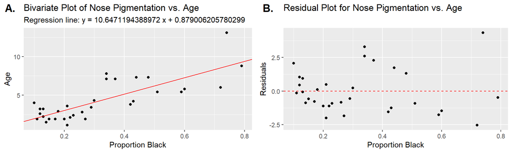

```r
library(cowplot)

regression.plots <- function(reg.model){
regression <- reg.model$regression
regression.df <- reg.model$regression.df

bi_var_marginal_histograms <- ggplot(regression.df, aes(x = X, y= Y)) + geom_point() + labs(x = "Proportion Black", y = "Age", title =  "Bivariate Plot of Nose Pigmentation vs. Age", subtitle = paste("Regression line: y =", regression$slope, "x +",regression$intercept))
bi_var_marginal_histograms_abline <-  bi_var_marginal_histograms + geom_abline(slope = regression$slope, intercept = regression$intercept, color = "red")
ggMarginal(bi_var_marginal_histograms_abline, type = "histogram", bins = 11)
bi_var_marginal_histograms_abline

# Making a residual plot
residual_plot <- ggplot(regression.df, aes(X,residuals)) + geom_point() + geom_hline(yintercept = 0, color = 'red', linetype = 'dashed') + labs(x = "Proportion Black", y = "Residuals", title = "Residual Plot for Nose Pigmentation vs. Age", subtitle = "")

composite_plot_1 <- ggdraw() +
  draw_plot(bi_var_marginal_histograms_abline, 0, 0, width = .5) +
  draw_plot(residual_plot, 0.5, 0, width = .5) +
  draw_plot_label(c("A.", "B. "), c(0, 0.5), c(1, 1), size = 15)

composite_plot_1
}

##Parts a and b labled on figure as 'A' and 'B' respectively
regression.plots(reg.model)
```